# Notebook

### Deep nets don't seem to memorize too much when trained on real data

Here is an experiment from which I argue that neural nets, when trained on real data, learn without memorizing the training set.

So far I think I have only shown that neural nets don't learn by memorizing the **whole** dataset, but they might still learn by "memorizing" **some** examples.

Consider the following experiment:

- Unroll $T$ steps of SGD as a computation graph
- In a step $t$
  - we receive weights $W_{t-1}$, and input minibatch $x_t,y_t$ randomly sampled from $X,Y$ (a dataset of $N$ examples)
  - we compute the output $o_t$, the loss $l_t(y_t, o_t)$ and perform an SGD update to get $W_t = W_{t-1} - \alpha * \nabla_{W_{t-1}}l_t$
  - we compute the output $\hat{o}_t$, where $x_t$ is **considered constant** (but not $x_{t-1..0}$), and the corresponding loss $\hat{l}_t$
  - we compute $g_x^t = \|d\hat{l}_t/dx\|_1\;\;\;\forall x\in X$ via *"backprop through SGD"* (the recurrent connections being $W_{t-1}\to W_t$)

Here is my hypothesis: if $g_x$ is very high for some $x$s and low for all other $x$, then there are only a few $x$s that influenced $\hat{l}$ through $W$ to get a high gradient.

On a random noise dataset, the NN needs to memorize everything so $g_x$ will be high for all $x$, while on a normal structured dataset, once the NN learned some weight configuration from some $x$s, it doesn't need the other $x$s that would push it into this same configuration, so $g_x$ should be higher for some $x$ and lower for others.

Note that I need $\hat{l}$ instead of just $l$ because the gradient of $l_t$ wrt $x_t$ is usually quite higher than wrt to previous $x$s, since $x_t$ just occured in training. Also note that $\hat{l}$ is still quite influenced by $x_{t-1}$, so we also check the average $g_x$ through time, see Figure 3 & 4.

I will show 4 plots, all on 14x14 MNIST or 14x14 U[0,1] random X. For figure 1&2, The MLP has 1 hidden layer of 32 units.

In figure 1 we do this procedure with $N=1000$ examples.  
The y axis is $g^T_x$, and each line represents $T=100, 200, ...$.  
The x axis is the sorted $x$s, sorted by $g^T_x$ (re-sorted at each new $T$/line)

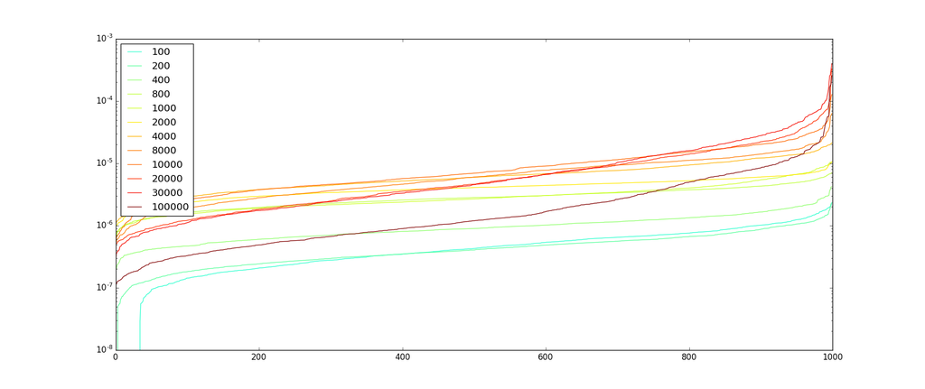

```python
from IPython.display import Image
Image(filename='./sorted_grads_avg_1000_examples.png')
############## FIGURE 1 ##############
```

To see if this means anything let's compare this to 1000 random U[0,1] examples.

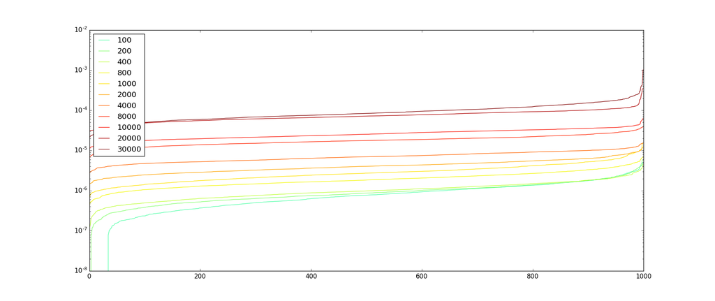

```python
Image(filename='./sorted_grads_avg_1000_random_examples.png')
############## FIGURE 2 ##############
```

Here we see that after a while ($T=30000$), virtually all examples are between $10^{-5}$ and $10^{-3.5}$, probably because the network *has* to memorize every example. The very small peak on the right is probably just due to the examples in the minibatch being more recent.

This difference between random $x$s and true $x$s leads me to believe that what I am measure makes a little bit of sense and is not a totally random measure.

The following figure, Figure 3, shows a similar plot to Fig 1 & 2, but instead shows the average $g$ in blue $$\bar{g}_x=\frac{1}{T}\sum_t g^t_x$$ and all the individual $g^t_x$s in transparent red to cyan behind the blue line representing the average. The $x$s are again sorted, by their $\bar{g}_x$

This is again on 14x14 mnist with 1000 examples. The way I interpret this figure is that even after averaging for examples being recently seen in the SGD process, the distribution is still unbalanced. Some examples are more important than others, but very few disproportionately so.

($T=10000$, this particular plot is 1 layer of 64 hidden units, but 32 hidden units looks the same, and two layers of 32 units also looks the same)

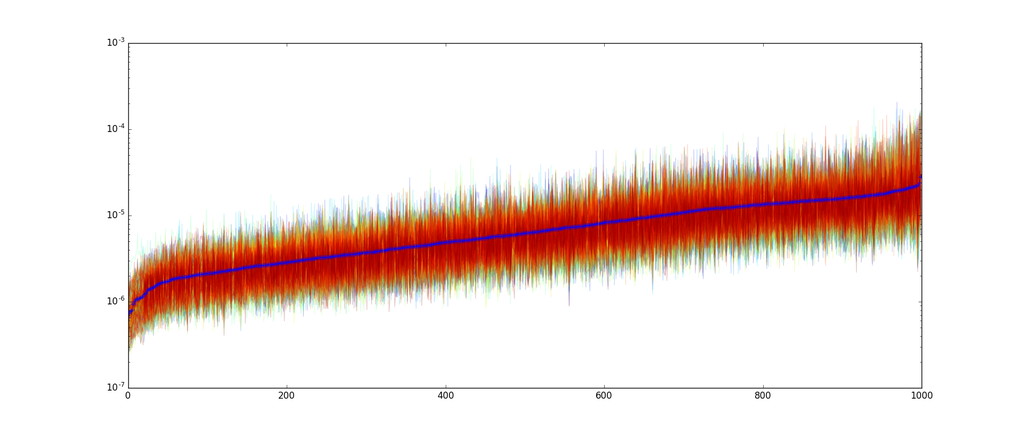

```python
Image(filename='./grads_decay_Nex1000_nh64_mb32.png')

############## FIGURE 3 ##############
```

```python
Image(filename='./top_20_x.png')
```

[output not shown]

.

Here is the same figure but for a uniform random $X$. Again, the network has to memorize so $g_x$ is high for all $x$.

(again $T=10000$, $X\sim U[0,1]$)

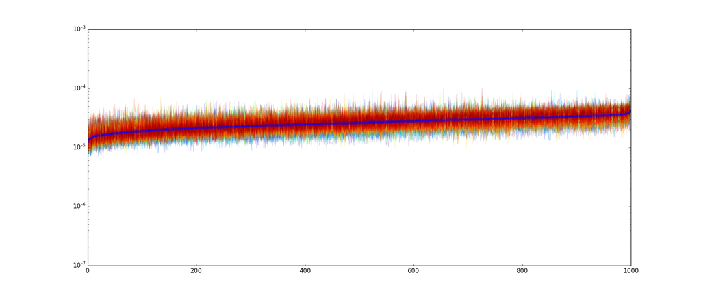

```python
Image(filename='./grads_decay_Nex1000_nh64_mb32_randX.png')

############## FIGURE 4 ##############
```

Here is a repeat of figure 1 and 2, but for $N=150$ examples.

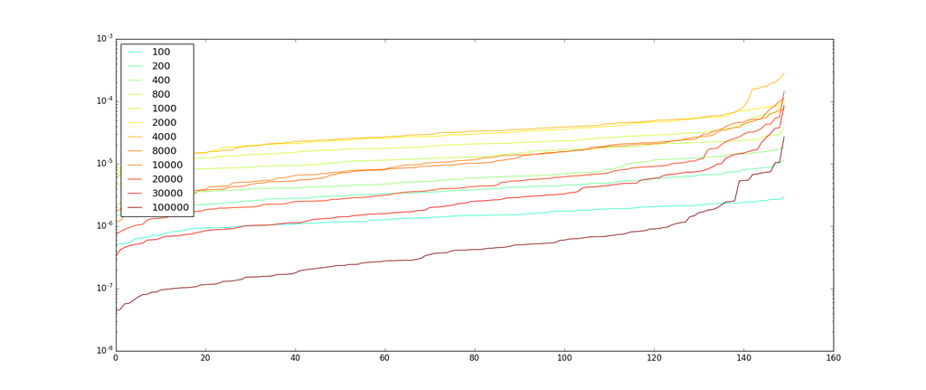

```python
Image(filename='./sorted_grads_avg_150_examples.png')
############## FIGURE 5 ##############
```

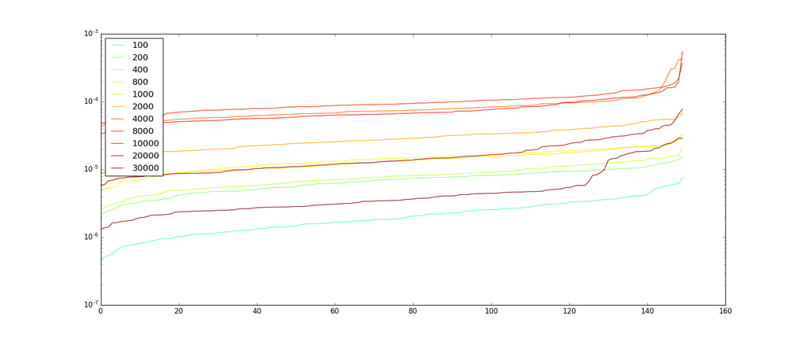

```python
Image(filename='./sorted_grads_avg_150_random_examples.png')
############## FIGURE 6 ##############
```

Here, I would argue that both these figures look relatively similar because from only 150 examples the network can just memorize anyways, so it doesn't bother to or can't generalize properly.

We also see that it overfits at some point and $g_x$ goes down for all $x$ probably because the weights are picking up minor differences in the pixel intensities of 1 or 2 pixels, sufficient to differentiate examples, and don't care about the rest of the pixels.

Here is a plot of $N$ lines, 1 per example, of the evolution of $g^t_x$ over time. Clearly when some $x$ is in a minibatch, its $g_x$ peaks alot, but there seem to be some lines that remain above the rest.

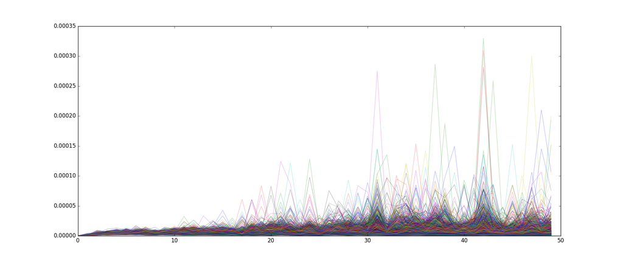

```python
Image(filename='./grads_plot_each_250.png')
############## FIGURE 7 ##############
```

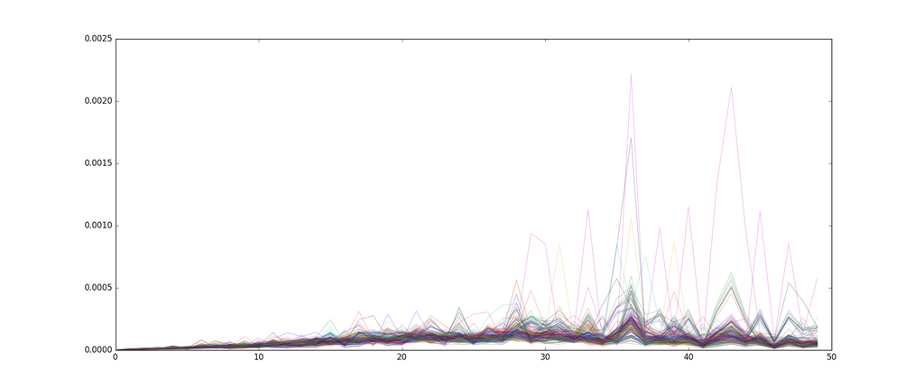

```python
Image(filename='./grads_plot_each_250_random.png')
############## FIGURE 8 ##############
```

Here is figure 1 but with a different dataset. Take $n\ll N$ images from small MNIST, and make an $N$-dataset out of those $n$ examples by simply adding different gaussian noise samples repeatedly.

My hypothesis is that if the neural network is a memorizing alogrithm, then it will only be sensible to $n$ examples, and not care about the rest, since they are just noisy copies of the original $n$ examples. If it isn't then most examples will have some sensitivity because they all contribute to the weight learning.

In the following figure, $n=100,N=1000$, it does look like it is very sensible to a few examples, but still remains relatively sensible to most examples in the dataset.

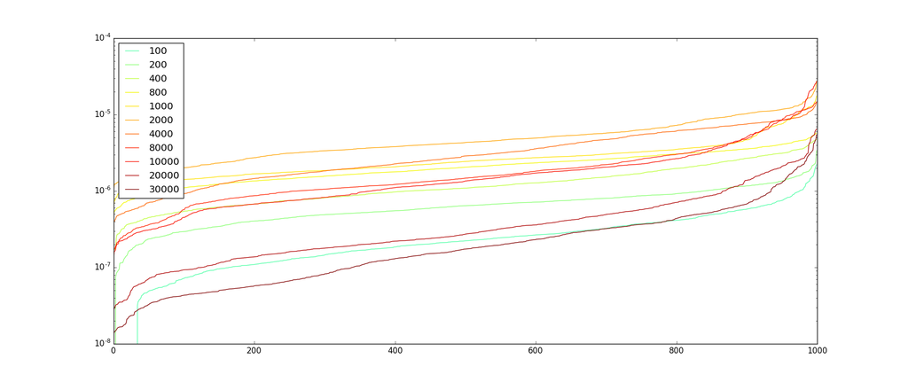

```python
Image(filename='./100_ex/grads_avg_2_all_1000.png')
############## FIGURE 9 ##############
```

$n=100,N=5000$, to me this again suggests that neural networks do *not* learn by memorizing. At least not the whole dataset.

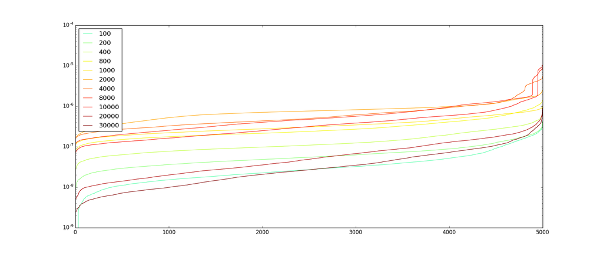

```python
Image(filename='./100_ex/grads_avg_2_all_5000.png')
############## FIGURE 9 ##############
```